# Into R Data Wrangling

## Sanity checks and quick plotting

Whenever we get data we want to be able to quickly assess the situation; does our data make sense?

Let’s do this with the RNA seq counts from our experiment you. First, take a minute and think about what you would expect (number of genes, number of replicates etc.)

```r
# reading in data
counts <- read.csv('~/work/cmm262-2020/Module_1/Data/tardbp_counts_with_length.csv', header = TRUE, stringsAsFactors = FALSE)

# check type
typeof(counts)
```

```
## [1] "list"
```

```r
# check dimensions
dim(counts)
```

```
## [1] 19021     6
```

```r
# check first few lines
head(counts)
```

|  | Geneid | Length | NT_shRNA_hepg2_rep1 | NT_shRNA_hepg2_rep2 | TARDBP_shRNA_hepg2_rep1 | TARDBP_shRNA_hepg2_rep2 |
| --- | --- | --- | --- | --- | --- | --- |
| 1 | ENSG00000227232.5_2 | 1351 | 27 | 42 | 40 | 35 |
| 2 | ENSG00000238009.6_6 | 3726 | 0 | 4 | 4 | 8 |
| 3 | ENSG00000237683.5 | 2661 | 22 | 20 | 16 | 27 |
| 4 | ENSG00000239906.1_5 | 323 | 6 | 2 | 3 | 7 |
| 5 | ENSG00000241860.6_5 | 6195 | 26 | 32 | 35 | 35 |
| 6 | ENSG00000228463.4 | 3954 | 77 | 69 | 63 | 67 |

Checking correlation between replicates

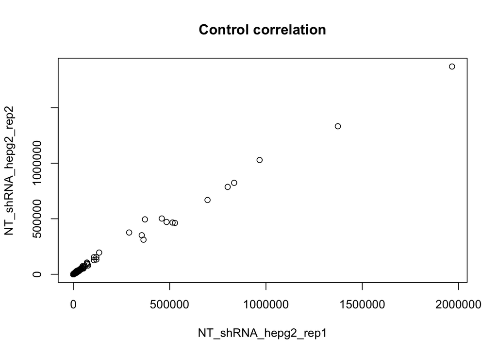

```r
plot(x = counts$NT_shRNA_hepg2_rep1, y = counts$NT_shRNA_hepg2_rep2, main = 'Control correlation', xlab = 'NT_shRNA_hepg2_rep1', ylab = 'NT_shRNA_hepg2_rep2')
```

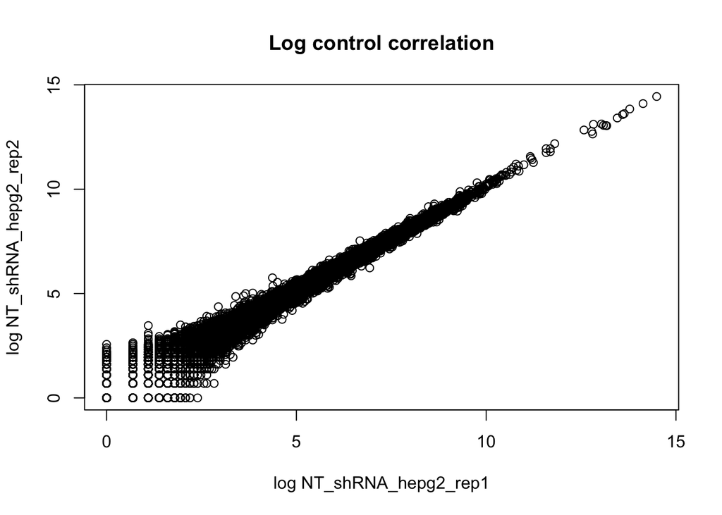

```r
# the above is not too informative so instead plot on a log-scale (log() coresponds to the natural log in R)
plot(x = log(counts$NT_shRNA_hepg2_rep1 + 1), y = log(counts$NT_shRNA_hepg2_rep2 + 1 ), main = 'Log control correlation', xlab = 'log NT_shRNA_hepg2_rep1', ylab = 'log NT_shRNA_hepg2_rep2')
```

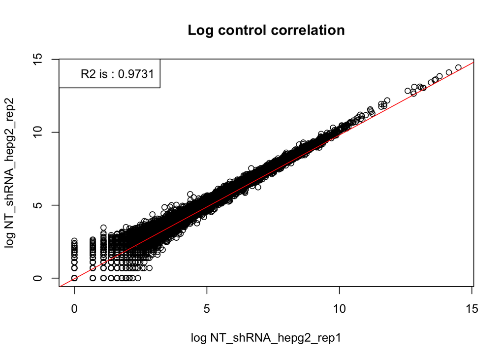

```r
# the above is already much better, but we would now like to quantify how closely they resemble one another
# to do so we use the 'r-squared' metric (goodness of fit measure between 0 and 1)
# because we are trying to determine a linear relationship we use a linear model: lm(Y ~ X)
# since we are working in log-space we might have to add a pseudo-count

fit <- lm(log(counts$NT_shRNA_hepg2_rep1 + 1) ~ log(counts$NT_shRNA_hepg2_rep2 + 1))
plot(x = log(counts$NT_shRNA_hepg2_rep1 + 1), y = log(counts$NT_shRNA_hepg2_rep2 + 1 ), main = 'Log control correlation', xlab = 'log NT_shRNA_hepg2_rep1', ylab = 'log NT_shRNA_hepg2_rep2')
abline(fit, col = 'red')
legend('topleft', legend = paste('R2 is :', format(summary(fit)$adj.r.squared,digits = 4)))
```

```r
s <- summary(fit)
```

Now let’s compare across experiments (what do we expect?)

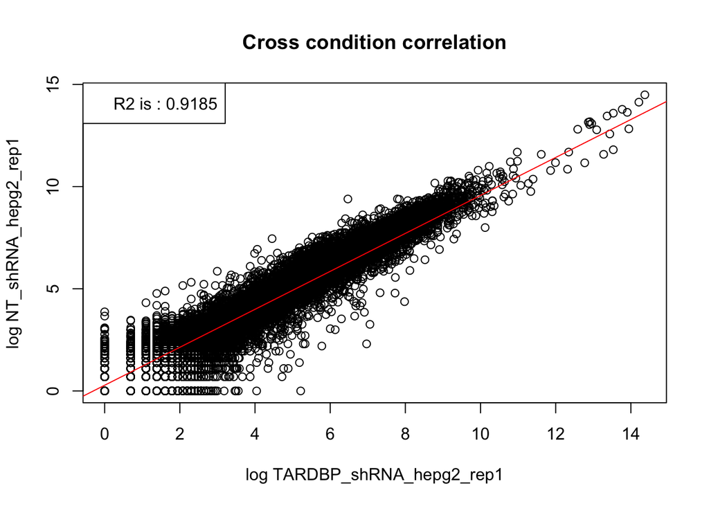

```r
fit2 <- lm(log(counts$TARDBP_shRNA_hepg2_rep1 + 1) ~ log(counts$NT_shRNA_hepg2_rep1 + 1))
plot(x = log(counts$TARDBP_shRNA_hepg2_rep1 + 1), y = log(counts$NT_shRNA_hepg2_rep1 + 1),
     main = 'Cross condition correlation', xlab = 'log TARDBP_shRNA_hepg2_rep1',
     ylab = 'log NT_shRNA_hepg2_rep1')
abline(fit2, col = 'red')
legend('topleft', legend = paste('R2 is :', format(summary(fit2)$adj.r.squared, digits = 4)) )
```

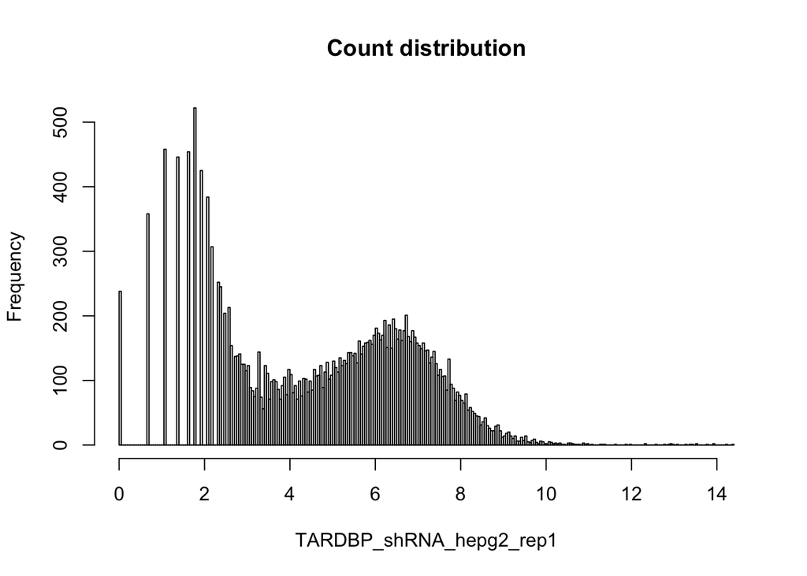

```r
# we can also look at the distribution of the counts themselves by using a histogram
hist(log(counts$TARDBP_shRNA_hepg2_rep1 + 1), main = 'Count distribution', xlab = 'TARDBP_shRNA_hepg2_rep1', ylab = 'Frequency', breaks = 500)
```

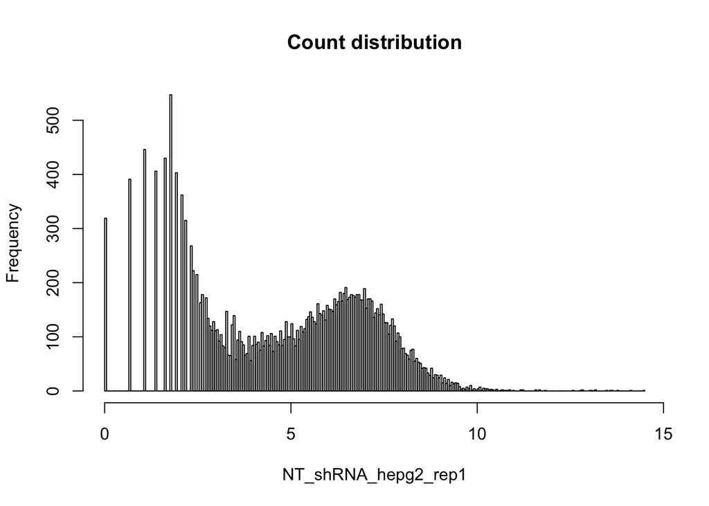

```r
hist(log(counts$NT_shRNA_hepg2_rep1 + 1), main = 'Count distribution', xlab = 'NT_shRNA_hepg2_rep1', ylab = 'Frequency', breaks = 500)
```

Let’s see what the general features are of counts across all samples:

```r
summary(rowSums(counts[,c(3:6)]))
```

```
##    Min. 1st Qu.  Median    Mean 3rd Qu.    Max.
##       5      60     713    5998    3313 7539335
```

For a gene having a combined count of over 7 million seems a bit high. How many such high-count cases are there?

```r
high.count <- 500000
length(which(rowSums(counts[,c(3:6)]) > high.count))
```

```
## [1] 19
```

```r
# how would you remove these rows?
filtered.counts <- counts[-which(rowSums(counts[,c(3:6)]) > high.count),]
dim(counts)
```

```
## [1] 19021     6
```

```r
dim(filtered.counts)
```

```
## [1] 19002     6
```

Assuming the above was our last filtering step and every subsequent analysis performed would be using ‘filtered.counts’ we want to save the dataframe.

There are different options for saving data but we will use a built in function to store our data as a .csv file

```r
# we specifically set row.names to false. See what happens if you omit this flag
write.csv(filtered.counts, file = 'example_filtering.csv', row.names = F)
getwd()
```

```
## [1] "/Users/d/work/cmm262-2020/Module_1/Templates"
```

```r
# 1. specify to save in desired format
# 2. plot desired figure
# 3. specify that plotting is done
pdf('scatter_plot.pdf')

fit <- lm(log(counts$NT_shRNA_hepg2_rep1 + 1) ~ log(counts$NT_shRNA_hepg2_rep2 + 1))
plot(x = log(counts$NT_shRNA_hepg2_rep1 + 1), y = log(counts$NT_shRNA_hepg2_rep2 + 1 ), main = 'Log control correlation', xlab = 'log NT_shRNA_hepg2_rep1', ylab = 'log NT_shRNA_hepg2_rep2')
abline(fit, col = 'red')
legend('topleft', legend = paste('R2 is :', format(summary(fit)$adj.r.squared,digits = 4)))

dev.off()
```